# German tank problem

Suppose four tanks are captured with the serial numbers 10, 256, 202, and 97. Assuming that each tank is numbered in sequence as they are built, how many tanks are there in total?

We will answer this question using Bayesian statistics. As opposed to Frequentist statistics which gives a single number, Bayesian statistics yields a probability distribution for the total number of tanks. Therefore, we need to calculate the distribution of total tanks $N$, given the serial numbers $D$, we apply the Bayes' Theorem: $$ P(N∣D) \propto P(D∣N)P(N) $$ where $P(D∣N)$ is the posterior distribution of $N$ given $D$, $P(D∣N)$ is the likelihood of $D$ given $N$, and $P(N)$ is the prior of $N$.

To build the model, first let's think about the likelihood, $P(D∣N)$, which gives the probability that we would see the serial numbers [10, 256, 202, 97], given the total number of tanks. To decide how to model the likelihood, we can think about how we would create our data. Simply, we just have some number of tanks, with serial numbers 1,2,3,...,N, and we uniformly draw four tanks from the group. Therefore, we should use a discrete uniform distribution.

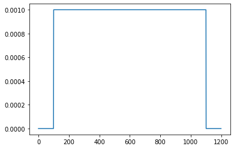

```python
from scipy.stats import uniform
import matplotlib.pyplot as pl
import numpy as np

x = np.arange(-100,1100,1)
s = uniform(0,1000).pdf(x)
pl.plot(s)
```

```python
data = [10, 256, 202, 97]
Nmax_guess = 10000

def likelihood(n):
    return uniform(1, n).pdf(data).sum()

def prior(n):
    return uniform(max(data), Nmax_guess).pdf(n)

def logprob(n):
    loglike = np.log(likelihood(n))
    logprior = np.log(prior(n))
    return loglike+logprior

n = 500
likelihood(n), prior(n), logprob(n)
```

```
(0.008, 0.0001, -14.038654109278482)
```

```python
import pymc3 as pm

with pm.Model() as model:
    N = pm.DiscreteUniform('p', lower=max(data), upper=10000)
    n = pm.DiscreteUniform('n', lower=1, upper=N, observed=data)

    prior = pm.sample_prior_predictive()
    trace = pm.sample(5000)
```

```
Multiprocess sampling (4 chains in 4 jobs)
Metropolis: [p]
The number of effective samples is smaller than 10% for some parameters.
```

```python
#posterior predictive check
ppc = pm.sample_posterior_predictive(trace, samples=500, model=model)
```

```python
np.asarray(ppc['n']).shape
```

```
(500, 4)
```

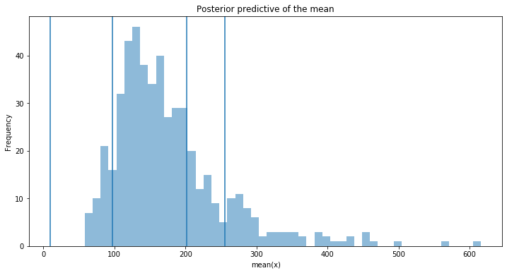

```python
_, ax = pl.subplots(figsize=(12, 6))
ax.hist([n.mean() for n in ppc['n']], bins=50, alpha=0.5)
[ax.axvline(x) for x in data]
ax.set(title='Posterior predictive of the mean', xlabel='mean(x)', ylabel='Frequency');
```

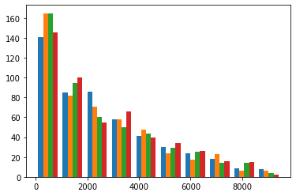

```python
pl.hist(prior['n']);
```

```python
import arviz as az

pm_data = az.from_pymc3(
            trace=trace,
            prior=prior,
            posterior_predictive=ppc,
            coords={'serial': data}
)
```

```
arviz.data.io_pymc3 - WARNING - posterior predictive variable n's shape not compatible with number of chains and draws. This can mean that some draws or even whole chains are not represented.
```

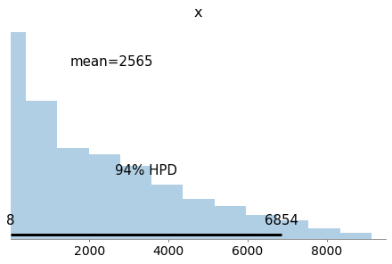

```python
az.plot_posterior(prior['n']);
```

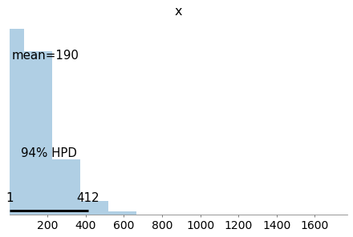

```python
az.plot_posterior(ppc['n']);
```

[output not shown]

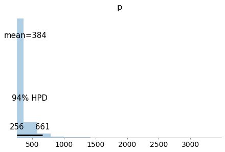

```python
pm.plot_posterior(trace)
```

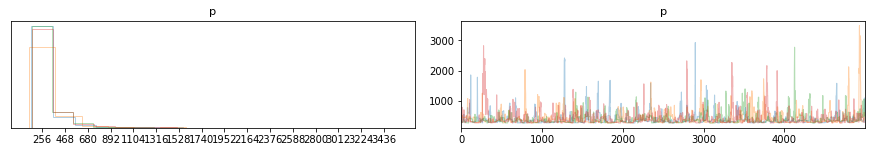

```python
az.plot_trace(trace, hist_kwargs={'histtype': 'step'});
```

Note that this problem appeared in [sampyl](http://mcleonard.github.io/sampyl/examples/german_tank_problem.html).